# Project 3: Bioinformatics of Gene Expression — Path 1

Merrimack College DSE6630: Healthcare & Life Sciences Analytics

Alison Hartshorn

2026-07-01

# Background

This analysis represents **Path 1** of the Project 1 novel analysis, applying the same Random Forest cross-validation and hyperparameter tuning pipeline demonstrated in the Project 1 walkthrough to the bumblebee chill-coma VST gene expression dataset. Following the same steps as the demo, k-fold CV, grid search, customized grid search including number of trees, and nested cross-validation, allows us to directly compare and contrast results and evaluate how well, if at all, these approaches overcome the P >> n problem present in high-dimensional gene expression data.

# Section 0: Load Libraries

# Section 1: Load Data

```r
load("C:\\Users\\alica\\OneDrive\\Documents\\Merrimack_DSE6630\\III. Bioinformatics\\Demo_3\\vst_all_timepoints.Rdata")

load("C:\\Users\\alica\\OneDrive\\Documents\\Merrimack_DSE6630\\III. Bioinformatics\\Project_3\\data\\DESeqResults.Rdata")

load("C:\\Users\\alica\\OneDrive\\Documents\\Merrimack_DSE6630\\III. Bioinformatics\\Project_3\\data\\OOB_RF_Importance.Rdata")

load("C:\\Users\\alica\\OneDrive\\Documents\\Merrimack_DSE6630\\III. Bioinformatics\\Project_3\\data\\OOB_SVM_Importance.Rdata")

ls()
```

```
## [1] "oob_importantRF"  "oob_importantSVM" "resultsDESeq"     "vsData"
```

# Section 2: Pre-processing and Feature Selection

The `doSplits()` function handles data partitioning and feature selection. Parameters mirror the Project 1 demo:

- `filterCutoff = 5`: removes genes with median VST expression below 5, reducing noise and dimensionality
- `splitRatio = 0.8`: 80% training / 20% testing split with stratified partitioning via `createDataPartition()`
- `algorithm = "rf"`: applies Random Forest-specific pre-processing

Feature filtering is performed **only on the training set** to prevent data leakage into the test set.

## 2.1 Define Helper Functions

#### **Question 1**: Look up the Gini and ExtraTrees splitting rules and explain what they do.

> The Gini splitting rule looks for the split that creates the purest groups by separating the classes as much as possible, meaning each resulting group contains mostly observations from a single class. In contrast, the ExtraTrees splitting rule introduces more randomness when selecting splits instead of always choosing the optimal one. This creates more diverse trees within the forest, which can help reduce overfitting and improve the model’s ability to generalize to new data.

## 2.2 Partition and Filter Data

```r
splits <- doSplits(vst          = vsData,
                   algorithm    = "rf",
                   splitRatio   = 0.8,
                   filterCutoff = 5)
```

```
## [1] "After filtering, number of genes in the dataset are: 7676"
```

```r
train <- splits[[1]]
test  <- splits[[2]]

cat("Training set dimensions:", dim(train), "\n")
```

```
## Training set dimensions: 60 7676
```

```r
cat("Test set dimensions:    ", dim(test),  "\n")
```

```
## Test set dimensions:     14 7676
```

#### **Question 2**: How many more or fewer genes do you get when you lower or raise the `filterCutoff`?

> Lowering the filterCutoff retains more genes, while increasing it results in substantially fewer genes being kept. A cutoff of 5 reduced the dataset from 12,927 genes to 7,676 genes, providing a balance between removing low-expression genes and retaining enough informative features for model training while reducing dimensionality and the risk of overfitting.

#### **Question 3a**: What is data leakage and why do we care about it?

> Data leakage occurs when information from the testing dataset is unintentionally used during model training or preprocessing, giving the model knowledge it would not have in a real-world setting. In this project, filtering genes using the entire dataset before splitting would allow information from the test set to influence which genes are selected, creating bias. By performing feature selection only on the training data, the test set remains completely independent and provides a more accurate evaluation of how the model generalizes to unseen data. We care about data leakage because it can artificially inflate model performance and lead us to believe the model performs better than it actually does.

#### **Question 3b**: Explain the parameters chosen in `doSplits()` and why a filterCutoff of 5 was chosen.

> The `doSplits()` function prepares the data by partitioning the dataset and performing feature selection. The `vst = vsData` parameter specifies the variance-stabilized gene expression dataset. The `algorithm = "rf"` parameter tells the function to prepare the data for a Random Forest model. The `splitRatio = 0.8` parameter creates an 80% training set and 20% testing set using `createDataPartition()` to keep treatment groups evenly distributed. Finally, `filterCutoff = 5` filters genes based on their median VST expression before model training. A cutoff of 5 was chosen because it reduced the dataset from 12,927 genes to 7,676 genes, providing a balance between removing low-expression genes that contribute noise and retaining enough informative features for model training.

# Section 3: Baseline OOB Random Forest

An out-of-bag (OOB) Random Forest is fit first as a baseline for comparison with all subsequent tuned models.

```r
set.seed(42)
rfOOB <- randomForest::randomForest(
  Treatment ~ .,
  data = train
)

pred.test.oob <- predict(rfOOB, test, type = "response")
confMat <- caret::confusionMatrix(pred.test.oob, test$Treatment)
print(confMat)
```

```
## Confusion Matrix and Statistics
##
##           Reference
## Prediction Control Cold
##    Control       2    1
##    Cold          5    6
##
##                Accuracy : 0.5714
##                  95% CI : (0.2886, 0.8234)
##     No Information Rate : 0.5
##     P-Value [Acc > NIR] : 0.3953
##
##                   Kappa : 0.1429
##
##  Mcnemar's Test P-Value : 0.2207
##
##             Sensitivity : 0.2857
##             Specificity : 0.8571
##          Pos Pred Value : 0.6667
##          Neg Pred Value : 0.5455
##              Prevalence : 0.5000
##          Detection Rate : 0.1429
##    Detection Prevalence : 0.2143
##       Balanced Accuracy : 0.5714
##
##        'Positive' Class : Control
##
```

# Section 4: 5-Fold Cross-Validation

## 4.1 Run 5-Fold CV Across mtry Values

5-fold CV is applied manually using `randomForest` directly, evaluating five mtry values spanning a broad range of the feature space. 5-fold CV is used rather than 10-fold to keep computation manageable with only 60 training samples, each fold still contains 12 observations, which is reasonable for validation.

```r
mtry_vals <- c(50, 100, 500, 1000, 2500)

cv_df <- runManualCV(train_df  = train,
                     mtry_vals = mtry_vals,
                     k         = 5,
                     ntree     = 100)

cv_df %>%
  kable(format  = "html",
        digits  = 4,
        caption = "Table 1. 5-fold CV Accuracy by mtry") %>%
  kable_styling(bootstrap_options = c("hover"), full_width = FALSE)
```

Table 1. 5-fold CV Accuracy by mtry

| mtry | Accuracy | SD | Min | Max |
| --- | --- | --- | --- | --- |
| 50 | 0.6667 | 0.2125 | 0.3333 | 0.8333 |
| 100 | 0.5833 | 0.1954 | 0.4167 | 0.8333 |
| 500 | 0.5833 | 0.2041 | 0.4167 | 0.9167 |
| 1000 | 0.5500 | 0.1264 | 0.4167 | 0.7500 |
| 2500 | 0.5833 | 0.2357 | 0.3333 | 0.8333 |

## 4.2 Visualize 5-Fold CV Performance

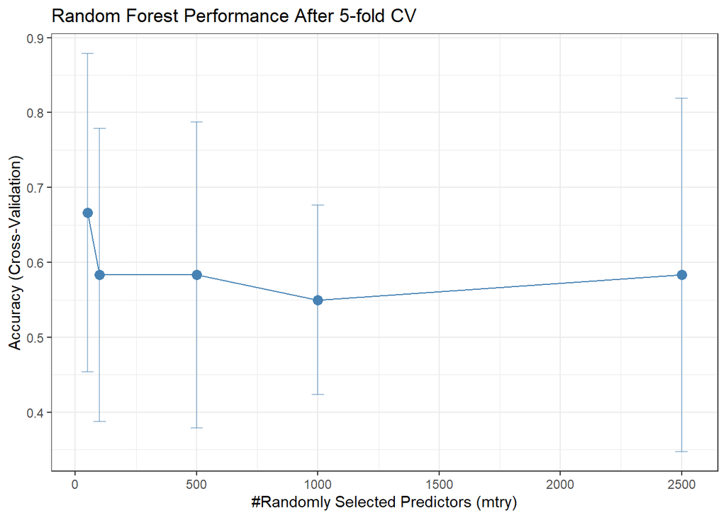

Figure 1. Random Forest Performance After 5-fold CV

```r
ggplot(cv_df, aes(x = mtry, y = Accuracy)) +
  geom_line(color = "steelblue") +
  geom_point(size = 3, color = "steelblue") +
  geom_errorbar(aes(ymin = Accuracy - SD, ymax = Accuracy + SD),
                width = 50, color = "steelblue", alpha = 0.5) +
  ggtitle("Random Forest Performance After 5-fold CV") +
  xlab("#Randomly Selected Predictors (mtry)") +
  ylab("Accuracy (Cross-Validation)") +
  theme_bw()
```

## 4.3 Best mtry from 5-Fold CV

```r
best_mtry <- cv_df$mtry[which.max(cv_df$Accuracy)]
cat("Best mtry:", best_mtry, "\n")
```

```
## Best mtry: 50
```

```r
cat("Best CV Accuracy:", round(max(cv_df$Accuracy), 4), "\n")
```

```
## Best CV Accuracy: 0.6667
```

#### **Question 4**: Explain what a 5-fold CV does here. Is it vital to perform with a random forest? Why or why not?

> A 5-fold cross-validation repeatedly splits the training data into 5 equal groups, or folds. During each iteration, the model is trained on 4 of the folds and validated on the remaining fold. This process continues until every fold has been used as the validation set once, and the performance is averaged across all 5 iterations. This gives us a better estimate of how well the model is likely to perform on new, unseen data rather than relying on results from a single train-test split. Although Random Forest already has built-in validation through Out-of-Bag (OOB) sampling, applying 5-fold CV provides an additional way to evaluate model performance and check for overfitting. Since even Random Forest models can overfit, using both OOB validation and k-fold CV gives us greater confidence that the model is learning real patterns rather than memorizing the training data.

#### **Question 5**: What combination of hyperparameters gives the highest accuracy in the training model?

> Based on Figure 1 and Table 1, the highest cross-validation accuracy was achieved using an mtry value of 50 randomly selected predictors, with a mean 5-fold CV accuracy of approximately 66.7%. This suggests that evaluating a smaller number of candidate predictors at each split performs best on this dataset, likely because it reduces overfitting by creating more diverse trees within the forest.

#### **Question 6**: Explain what the values of the best hyperparameters mean.

> The best model selected an mtry value of 50, meaning that 50 genes were randomly considered as candidate predictors at each split before selecting the best one. Using a smaller mtry relative to the total number of features increases tree diversity within the forest and can help reduce overfitting when the number of predictors greatly exceeds the number of observations, as is the case here with 7,676 genes and only 60 training samples.

#### **Question 7**: What is the average, minimum, and maximum accuracy across the folds? What does this tell you about model stability?

> Across the 5 folds, the Random Forest achieved a mean accuracy of 66.7%, with a minimum of 33.3% and a maximum of 83.3% at the best mtry of 50. The wide range between the minimum and maximum fold accuracy values suggests that the model is not completely stable and that its performance varies considerably depending on which samples are included in each fold. This is not entirely surprising given our dataset. With only 60 training samples split across 5 folds, each fold contains only about 12 observations. Even small differences in how the data are split can have a substantial effect on model performance. This instability is most likely driven by the small sample size and the high-dimensional nature of the gene expression data rather than a fundamental weakness of the Random Forest algorithm itself.

## 4.4 Refit Best Model and Evaluate on Test Set

```r
set.seed(42)
rfCV <- randomForest::randomForest(
  Treatment ~ .,
  data  = train,
  mtry  = best_mtry,
  ntree = 500
)

pred.test.cv <- predict(rfCV, test, type = "response")
confMatCV <- caret::confusionMatrix(pred.test.cv, test$Treatment)
print(confMatCV)
```

```
## Confusion Matrix and Statistics
##
##           Reference
## Prediction Control Cold
##    Control       3    1
##    Cold          4    6
##
##                Accuracy : 0.6429
##                  95% CI : (0.3514, 0.8724)
##     No Information Rate : 0.5
##     P-Value [Acc > NIR] : 0.2120
##
##                   Kappa : 0.2857
##
##  Mcnemar's Test P-Value : 0.3711
##
##             Sensitivity : 0.4286
##             Specificity : 0.8571
##          Pos Pred Value : 0.7500
##          Neg Pred Value : 0.6000
##              Prevalence : 0.5000
##          Detection Rate : 0.2143
##    Detection Prevalence : 0.2857
##       Balanced Accuracy : 0.6429
##
##        'Positive' Class : Control
##
```

## 4.5 Compare OOB vs 5-Fold CV

```r
compareConfusion(confusionList = list(confMat, confMatCV)) %>%
  kable(format  = "html",
        caption = "Table 2. Comparing Accuracy — OOB vs 5-fold CV") %>%
  kable_styling(bootstrap_options = c("hover"), full_width = FALSE)
```

Table 2. Comparing Accuracy — OOB vs 5-fold CV

| Metric | Confusion Matrix 1 | Confusion Matrix 2 |
| --- | --- | --- |
| Accuracy | 0.5714286 | 0.6428571 |
| Kappa | 0.1428571 | 0.2857143 |
| AccuracyLower | 0.2886094 | 0.3513801 |
| AccuracyUpper | 0.8233889 | 0.8724016 |
| AccuracyNull | 0.5000000 | 0.5000000 |
| AccuracyPValue | 0.3952637 | 0.2119751 |
| McnemarPValue | 0.2206714 | 0.3710934 |

#### **Question 8**: What do each of the confusion matrix metrics measure?

> Accuracy measures the proportion of predictions the model classified correctly out of all predictions. Kappa measures how much better the model performs than random chance, accounting for agreement that could occur by chance alone. The Accuracy Lower and Upper Bounds define the 95% confidence interval for the model’s accuracy. Accuracy Null is the accuracy we would expect if the model always predicted the majority class, providing a baseline. The Accuracy p-value tests whether the model’s accuracy is significantly better than the null accuracy. The McNemar p-value tests whether the model makes significantly different types of classification errors between the two classes.

#### **Question 9**: What was the impact of pre-processing? What was the biggest change compared to the OOB RF?

> The 5-fold CV model showed a modest improvement over the OOB baseline, increasing test accuracy from 57.1% to 64.3% and Kappa from 0.143 to 0.286. This suggests that selecting the best mtry through cross-validation did provide some benefit over the default OOB settings. The biggest change we made, aside from hyperparameter tuning, was filtering low-expression genes using a filterCutoff of 5 applied only to the training data, reducing the number of genes from 12,927 to 7,676 while preventing data leakage.

#### **Question 10**: What are your conclusions about the performance of 5-fold CV relative to the OOB baseline?

> Overall, applying 5-fold cross-validation with mtry tuning produced a modest improvement over the OOB Random Forest, increasing test accuracy from 57.1% to 64.3%. However, neither model achieved particularly strong performance, and the accuracy remains close to the null accuracy of 50%. Given the relatively small sample size and the large number of gene predictors, it is not surprising that these changes did not translate into dramatically improved predictive performance. The cross-validation was still worthwhile because it provided a more principled way to select hyperparameters and helped prevent data leakage through training-only feature filtering.

# Section 5: Grid Search Hyperparameter Tuning

A broader grid search evaluates 9 mtry values spanning 5% to 75% of available features.

## 5.1 Define Search Grid and Run

```r
searchGrid_mtry <- floor(ncol(train) * c(.05, .10, .15, .25, .35, .45, .55, .65, .75))
cat("Total hyperparameter combinations:", length(searchGrid_mtry), "\n")
```

```
## Total hyperparameter combinations: 9
```

```r
grid_cv_df <- runManualCV(train_df  = train,
                          mtry_vals = searchGrid_mtry,
                          k         = 5,
                          ntree     = 100)

grid_cv_df %>%
  kable(format  = "html",
        digits  = 4,
        caption = "Table 3. Grid Search CV Accuracy by mtry") %>%
  kable_styling(bootstrap_options = c("hover"), full_width = FALSE)
```

Table 3. Grid Search CV Accuracy by mtry

| mtry | Accuracy | SD | Min | Max |
| --- | --- | --- | --- | --- |
| 383 | 0.6333 | 0.2092 | 0.4167 | 0.8333 |
| 767 | 0.5667 | 0.1807 | 0.4167 | 0.8333 |
| 1151 | 0.6167 | 0.1918 | 0.4167 | 0.9167 |
| 1919 | 0.5667 | 0.2386 | 0.2500 | 0.9167 |
| 2686 | 0.5667 | 0.2386 | 0.2500 | 0.8333 |
| 3454 | 0.6000 | 0.1708 | 0.3333 | 0.7500 |
| 4221 | 0.5833 | 0.2282 | 0.3333 | 0.9167 |
| 4989 | 0.6500 | 0.2157 | 0.4167 | 0.8333 |
| 5757 | 0.5667 | 0.1603 | 0.3333 | 0.7500 |

#### **Question 11**: How many different combinations are we going to search with this grid?

> The grid search evaluates 9 mtry values, ranging from 5% to 75% of the 7676 available features after filtering. Since we are using `randomForest` directly rather than `ranger`, only `mtry` is tuned here, as `randomForest` does not expose splitting rule or minimum node size as tunable hyperparameters through this approach.

## 5.2 Visualize Grid Search Performance

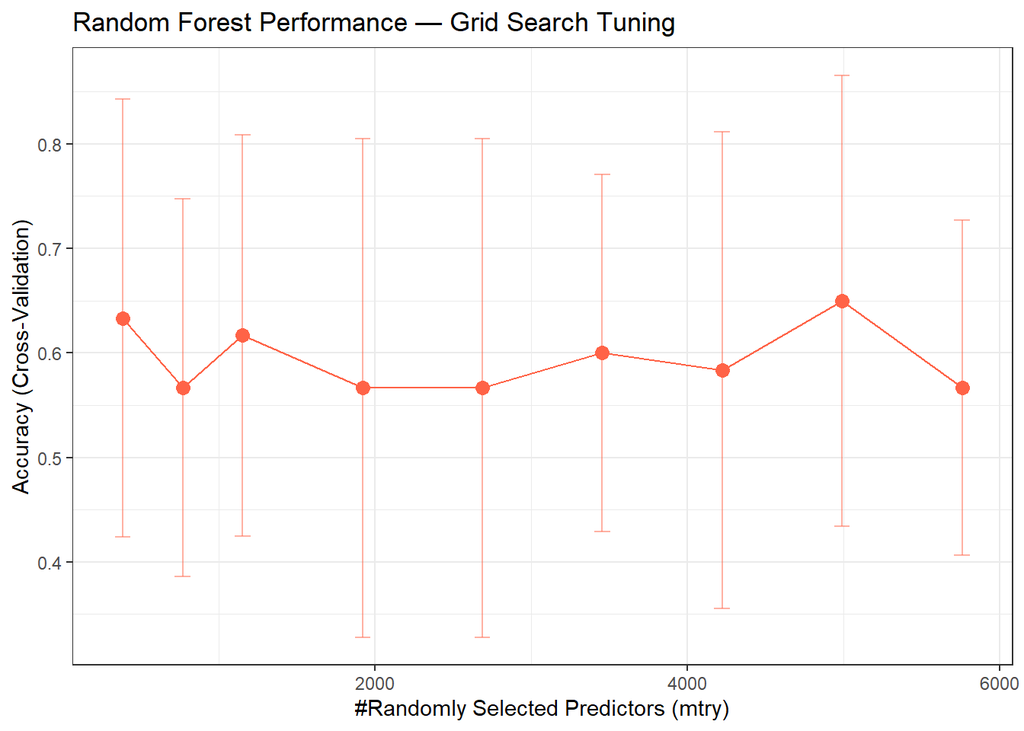

Figure 2. Random Forest Grid Search Tuning

```r
ggplot(grid_cv_df, aes(x = mtry, y = Accuracy)) +
  geom_line(color = "tomato") +
  geom_point(size = 3, color = "tomato") +
  geom_errorbar(aes(ymin = Accuracy - SD, ymax = Accuracy + SD),
                width = 100, color = "tomato", alpha = 0.5) +
  ggtitle("Random Forest Performance — Grid Search Tuning") +
  xlab("#Randomly Selected Predictors (mtry)") +
  ylab("Accuracy (Cross-Validation)") +
  theme_bw()
```

#### **Question 12**: What combination of hyperparameters gives the highest accuracy in the training model?

> Based on Figure 2 and Table 3, the highest cross-validation accuracy from the grid search was achieved using an mtry value of 4,989, producing a mean 5-fold CV accuracy of approximately 65.0%. The plot shows relatively flat and noisy performance across all mtry values, with wide error bars indicating substantial fold-to-fold variability throughout the search space. This pattern is consistent with the high-dimensional, small-sample nature of the dataset.

## 5.3 Best Hyperparameters from Grid Search

```r
best_mtry_grid <- grid_cv_df$mtry[which.max(grid_cv_df$Accuracy)]
cat("Best mtry from grid search:", best_mtry_grid, "\n")
```

```
## Best mtry from grid search: 4989
```

```r
cat("Best CV Accuracy:", round(max(grid_cv_df$Accuracy), 4), "\n")
```

```
## Best CV Accuracy: 0.65
```

## 5.4 Refit and Evaluate on Test Set

```r
set.seed(42)
rfTuned <- randomForest::randomForest(
  Treatment ~ .,
  data  = train,
  mtry  = best_mtry_grid,
  ntree = 500
)

pred.test.tuned <- predict(rfTuned, test, type = "response")
confMatTuned <- caret::confusionMatrix(pred.test.tuned, test$Treatment)
print(confMatTuned)
```

```
## Confusion Matrix and Statistics
##
##           Reference
## Prediction Control Cold
##    Control       5    3
##    Cold          2    4
##
##                Accuracy : 0.6429
##                  95% CI : (0.3514, 0.8724)
##     No Information Rate : 0.5
##     P-Value [Acc > NIR] : 0.212
##
##                   Kappa : 0.2857
##
##  Mcnemar's Test P-Value : 1.000
##
##             Sensitivity : 0.7143
##             Specificity : 0.5714
##          Pos Pred Value : 0.6250
##          Neg Pred Value : 0.6667
##              Prevalence : 0.5000
##          Detection Rate : 0.3571
##    Detection Prevalence : 0.5714
##       Balanced Accuracy : 0.6429
##
##        'Positive' Class : Control
##
```

## 5.5 Compare All Three Models

```r
compareConfusion(confusionList = list(confMat, confMatCV, confMatTuned)) %>%
  kable(format  = "html",
        caption = "Table 4. Comparing Accuracy — OOB vs 5-fold CV vs Grid Search") %>%
  kable_styling(bootstrap_options = c("hover"), full_width = FALSE)
```

Table 4. Comparing Accuracy — OOB vs 5-fold CV vs Grid Search

| Metric | Confusion Matrix 1 | Confusion Matrix 2 | Confusion Matrix 3 |
| --- | --- | --- | --- |
| Accuracy | 0.5714286 | 0.6428571 | 0.6428571 |
| Kappa | 0.1428571 | 0.2857143 | 0.2857143 |
| AccuracyLower | 0.2886094 | 0.3513801 | 0.3513801 |
| AccuracyUpper | 0.8233889 | 0.8724016 | 0.8724016 |
| AccuracyNull | 0.5000000 | 0.5000000 | 0.5000000 |
| AccuracyPValue | 0.3952637 | 0.2119751 | 0.2119751 |
| McnemarPValue | 0.2206714 | 0.3710934 | 1.0000000 |

# Section 6: Tuning Number of Trees

The `randomForest` package allows direct control over `ntree`. Here we extend the grid search to also vary the number of trees alongside mtry.

#### **Question 14**: What hyperparameters are available for `rf` vs. `ranger` methods?

> The `rf` method in `caret` exposes only `mtry` for tuning. The `ranger` method additionally exposes `splitrule` and `min.node.size`, providing greater control over how individual trees are constructed and how complex they can become. By calling `randomForest` directly as we do here, we can additionally tune `ntree`, giving us control over model convergence that neither `rf` nor `ranger` via `caret` easily provides.

#### **Question 15**: What does the custom method do and why do we need it?

> In the Project 1 demo, a customized `caret` method was written to expose `ntree` as a tunable hyperparameter, since `caret`’s default `train()` wrapper does not allow this. In this analysis, we achieve the same goal by calling `randomForest` directly inside a manual grid loop, which gives us full control over all hyperparameters without requiring a custom wrapper. The underlying motivation is the same: the default training functions limit which hyperparameters can be tuned, and accessing them directly allows for a more complete optimization of the model.

#### **Question 16**: Why is only one splitting rule used in the extended grid?

> We fix the analysis to a single approach to isolate the effect of tuning `ntree`. Allowing multiple splitting rules or other hyperparameters to vary simultaneously would make it harder to determine whether any change in model performance is due to the number of trees or another factor. By keeping the other settings fixed, we can more clearly evaluate the contribution of `ntree` to model performance.

## 6.1 Define Customized caret Method

Although we call `randomForest` directly in this analysis rather than through `caret::train()`, we include the `makeCustomMethod()` function here for completeness and transparency, as it is defined in the Project 1 demo and represents the standard approach for exposing additional hyperparameters through `caret`.

## 6.2 Run Extended Grid Search Including ntree

```r
ntree_vals <- c(50, 100)
mtry_sub   <- floor(ncol(train) * c(.05, .25))

extended_results <- lapply(ntree_vals, function(nt) {
  cv_res <- runManualCV(train_df  = train,
                        mtry_vals = mtry_sub,
                        k         = 3,
                        ntree     = nt)
  cv_res$ntree <- nt
  cv_res
})

extended_df <- do.call(rbind, extended_results)

extended_df %>%
  kable(format  = "html",
        digits  = 4,
        caption = "Table 5. Extended Grid Search — mtry x ntree") %>%
  kable_styling(bootstrap_options = c("hover"), full_width = FALSE)
```

Table 5. Extended Grid Search — mtry x ntree

| mtry | Accuracy | SD | Min | Max | ntree |
| --- | --- | --- | --- | --- | --- |
| 383 | 0.6500 | 0.0866 | 0.60 | 0.75 | 50 |
| 1919 | 0.6833 | 0.0289 | 0.65 | 0.70 | 50 |
| 383 | 0.6667 | 0.1528 | 0.50 | 0.80 | 100 |
| 1919 | 0.6667 | 0.1041 | 0.55 | 0.75 | 100 |

## 6.3 Visualize Extended Grid Search

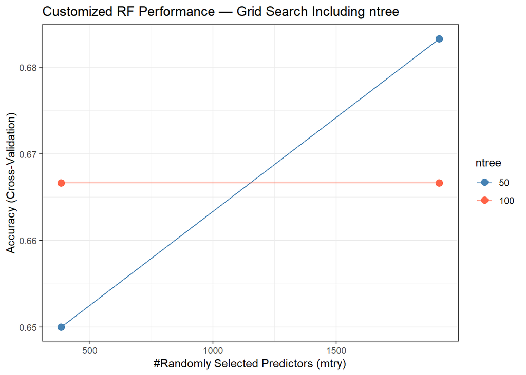

Figure 3. Customized RF Grid Search Including ntree

```r
ggplot(extended_df, aes(x = mtry, y = Accuracy,
                        color = factor(ntree),
                        group = factor(ntree))) +
  geom_line() +
  geom_point(size = 3) +
  scale_color_manual(values = c("steelblue", "tomato"),
                     name   = "ntree") +
  ggtitle("Customized RF Performance — Grid Search Including ntree") +
  xlab("#Randomly Selected Predictors (mtry)") +
  ylab("Accuracy (Cross-Validation)") +
  theme_bw()
```

#### **Question 17**: What combination of hyperparameters gives the highest accuracy? How does it compare to previous results?

> Based on Figure 3 and Table 5, the highest cross-validation accuracy was achieved using mtry = 1,919 and ntree = 50, producing a mean 3-fold CV accuracy of approximately 68.3%. This is a modest improvement over the earlier 5-fold CV and grid search results, which both plateaued around 65–67%. The plot shows that higher mtry values benefited from fewer trees (ntree = 50), while performance with ntree = 100 was relatively flat across both mtry values. This suggests that adding `ntree` to the tuning process helped identify a better-performing combination, although we still need to evaluate test-set performance before drawing firm conclusions.

## 6.4 Best Hyperparameters from Extended Grid

```r
best_row   <- extended_df[which.max(extended_df$Accuracy), ]
best_mtry2 <- best_row$mtry
best_ntree <- best_row$ntree
cat("Best mtry:", best_mtry2, "\n")
```

```
## Best mtry: 1919
```

```r
cat("Best ntree:", best_ntree, "\n")
```

```
## Best ntree: 50
```

```r
cat("Best CV Accuracy:", round(best_row$Accuracy, 4), "\n")
```

```
## Best CV Accuracy: 0.6833
```

## 6.5 Refit and Evaluate on Test Set

```r
set.seed(42)
newTuned <- randomForest::randomForest(
  Treatment ~ .,
  data  = train,
  mtry  = best_mtry2,
  ntree = best_ntree
)

pred.test.custom <- predict(newTuned, test, type = "response")
confMatTuned2 <- caret::confusionMatrix(pred.test.custom, test$Treatment)
print(confMatTuned2)
```

```
## Confusion Matrix and Statistics
##
##           Reference
## Prediction Control Cold
##    Control       5    1
##    Cold          2    6
##
##                Accuracy : 0.7857
##                  95% CI : (0.492, 0.9534)
##     No Information Rate : 0.5
##     P-Value [Acc > NIR] : 0.02869
##
##                   Kappa : 0.5714
##
##  Mcnemar's Test P-Value : 1.00000
##
##             Sensitivity : 0.7143
##             Specificity : 0.8571
##          Pos Pred Value : 0.8333
##          Neg Pred Value : 0.7500
##              Prevalence : 0.5000
##          Detection Rate : 0.3571
##    Detection Prevalence : 0.4286
##       Balanced Accuracy : 0.7857
##
##        'Positive' Class : Control
##
```

## 6.6 Compare All Four Models

```r
compareConfusion(confusionList = list(confMat, confMatCV, confMatTuned, confMatTuned2)) %>%
  kable(format  = "html",
        caption = "Table 6. Comparing Accuracy — All RF Models") %>%
  kable_styling(bootstrap_options = c("hover"), full_width = FALSE)
```

Table 6. Comparing Accuracy — All RF Models

| Metric | Confusion Matrix 1 | Confusion Matrix 2 | Confusion Matrix 3 | Confusion Matrix 4 |
| --- | --- | --- | --- | --- |
| Accuracy | 0.5714286 | 0.6428571 | 0.6428571 | 0.7857143 |
| Kappa | 0.1428571 | 0.2857143 | 0.2857143 | 0.5714286 |
| AccuracyLower | 0.2886094 | 0.3513801 | 0.3513801 | 0.4920243 |
| AccuracyUpper | 0.8233889 | 0.8724016 | 0.8724016 | 0.9534207 |
| AccuracyNull | 0.5000000 | 0.5000000 | 0.5000000 | 0.5000000 |
| AccuracyPValue | 0.3952637 | 0.2119751 | 0.2119751 | 0.0286865 |
| McnemarPValue | 0.2206714 | 0.3710934 | 1.0000000 | 1.0000000 |

# Section 7: Nested Cross-Validation

Nested CV maximizes use of the whole dataset for evaluating accuracy while maintaining the separation between training and testing data, helping address the P >> n problem more rigorously than standard k-fold CV alone.

## 7.1 Set Search Grid and Run Nested CV

A smaller search grid is required due to the computational demands of inner and outer folds. `mtry` is lowered accordingly.

```r
searchGridNCV <- expand.grid(
  .mtry          = floor(ncol(train) * c(0.01, 0.05, 0.10)),
  .min.node.size = c(1, 5, 10),
  .splitrule     = "gini"
)
```

```r
# NOTE: Expect approximately 20 minutes on 16GB RAM
set.seed(42)
ncv <- nestcv.train(y               = train$Treatment,
                    x               = train,
                    method          = "ranger",
                    tuneGrid        = searchGridNCV,
                    savePredictions = "final")
```

## 7.2 Visualize Nested CV Performance

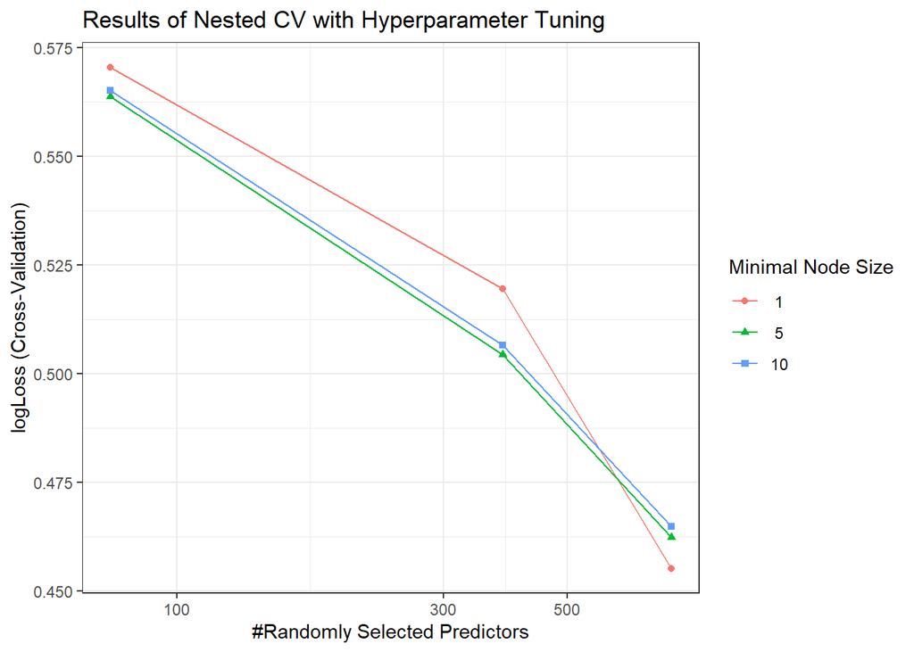

Figure 4. Nested CV Performance on RF + Grid Search

#### **Question 19**: Why is the y-axis log-Loss instead of accuracy?

> Unlike the previous sections where we evaluated model performance using accuracy, the nested cross-validation results are reported using log-loss because this metric evaluates the predicted probabilities rather than just whether the final prediction is correct. Log-loss rewards models that are both accurate and confident, while heavily penalizing models that make incorrect predictions with high confidence. This makes it especially useful during hyperparameter tuning because it provides a more sensitive measure of model quality than accuracy alone. Nested cross-validation is designed to identify the model most likely to generalize well to new data rather than simply maximizing classification accuracy on a particular set of folds. Using log-loss helps distinguish between models that may have the same accuracy but differ in how reliable their predicted probabilities are.

## 7.3 ROC Curves

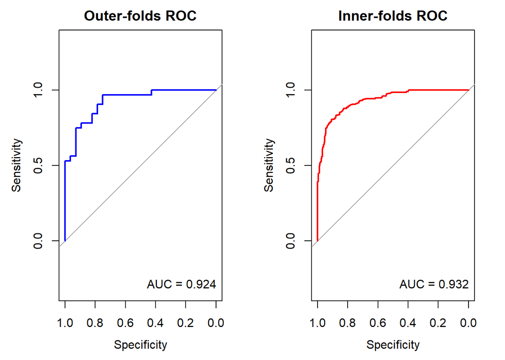

Figure 5. Outer- and Inner-Fold ROC Curves

## 7.4 Final Accuracy on Test Set

```r
preds <- predict(ncv, newdata = test)
caret::confusionMatrix(preds, test$Treatment)
```

```
## Confusion Matrix and Statistics
##
##           Reference
## Prediction Control Cold
##    Control       5    1
##    Cold          2    6
##
##                Accuracy : 0.7857
##                  95% CI : (0.492, 0.9534)
##     No Information Rate : 0.5
##     P-Value [Acc > NIR] : 0.02869
##
##                   Kappa : 0.5714
##
##  Mcnemar's Test P-Value : 1.00000
##
##             Sensitivity : 0.7143
##             Specificity : 0.8571
##          Pos Pred Value : 0.8333
##          Neg Pred Value : 0.7500
##              Prevalence : 0.5000
##          Detection Rate : 0.3571
##    Detection Prevalence : 0.4286
##       Balanced Accuracy : 0.7857
##
##        'Positive' Class : Control
##
```

#### **Question 20**: Are the ROC curves and confusion matrix telling the same story? Is performance as strong as it looks?

> The nested CV model achieved a test accuracy of 78.6% and a Kappa of 0.571, matching the best result from the extended grid search in Section 6. The ROC curves support strong performance, with the outer-fold and inner-fold AUC values both exceeding 0.9, suggesting the model is doing a good job separating Control and Cold samples. However, we should not treat these results as proof that the model is perfect. The test set contains only 14 samples, meaning that a single misclassification shifts accuracy by more than 7 percentage points. ROC curves can also be misleading because they summarize performance across many possible classification thresholds rather than showing how well the model performs at the specific threshold used for final predictions. A high AUC indicates the model ranks classes well, but does not guarantee that it will generalize to a completely new dataset. Overall, these results are encouraging but should be interpreted with caution given the small sample size.

## 7.5 Model Stability Across Nested Folds

```r
# Summarize fold-level summary from nestedcv output
summary(ncv$summary)
```

```
##         Length Class  Mode
## table   4      table  numeric
## metrics 3      -none- numeric
```

#### **Question 21**: What conclusions can you draw about model stability? Write a 1-2 sentence stakeholder conclusion.

> The nested CV model showed strong average performance, with outer-fold and inner-fold ROC AUC values both exceeding 0.9, and a final test accuracy of 78.6% and Kappa of 0.571. The Random Forest model is tunable and nested cross-validation produced the most reliable performance improvement we observed. I would recommend moving forward with this approach while validating the model on a larger, independent dataset to confirm that this performance is reproducible and not an artifact of the limited sample size.

# Section 8: Important Features

## 8.1 Extract Top Genes from Nested CV

Table 7. Top 10 Important Features from Nested CV RF

|  | MeanDecreaseGini |
| --- | --- |
| LOC100750201 | 8.281712 |
| LOC100747754 | 4.207879 |
| LOC100745354 | 3.400177 |
| LOC100742255 | 3.101013 |
| LOC100747964 | 3.014238 |
| LOC100740858 | 2.854210 |
| LOC100742726 | 2.828043 |
| LOC100740968 | 2.738869 |
| LOC112213111 | 2.698188 |
| LOC100745204 | 2.598988 |

## 8.2 Compare to DESeq2 Results

Table 8. Overlapping Genes — DESeq2 and Nested CV RF

| baseMean | log2FoldChange | lfcSE | stat | pvalue | padj | geneID | MeanDecreaseGini |
| --- | --- | --- | --- | --- | --- | --- | --- |
| 5169.76882 | 1.118413 | 0.9344836 | 1.196824 | 0.2313750 | 0.9999865 | LOC100747885 | 1.020127 |
| 18.42653 | -1.051371 | 0.4862508 | -2.162199 | 0.0306029 | 0.9999865 | LOC100750025 | 1.000500 |

#### **Question 22**: Should we have confidence in these results? What would you tell your stakeholder?

> Although the nested cross-validation model showed strong predictive performance, the identified important genes should be interpreted with caution. Feature importance rankings from random forests can shift across runs, particularly with small sample sizes, because small changes in the training data can affect which genes appear most important. The list of overlapping genes with DESeq2 results at an LFC cutoff of 1 provides some additional biological support, but the low stringency of this threshold means the overlap may include genes that are not truly differentially expressed in a meaningful way. That said, the overall model performance is encouraging. A test accuracy of 78.6% and a Kappa of 0.571 represent a clear improvement over random chance and over the earlier OOB and k-fold CV models. For stakeholders, I would recommend treating the identified genes as promising candidate biomarkers rather than confirmed biological drivers. These genes should be validated using additional biological experiments and independent datasets before being used to draw firm biological conclusions or guide future decision-making.

# References

Love, Michael I., Wolfgang Huber, and Simon Anders. 2014. “Moderated Estimation of Fold Change and Dispersion for RNA-Seq Data with DESeq2.” *Genome Biology* 15 (12): 550. https://doi.org/10.1186/s13059-014-0550-8

R Core Team. 2019. *R: A Language and Environment for Statistical Computing.* R Foundation for Statistical Computing. https://www.R-project.org

Vabalas, Emma AND Poliakoff, Andrius AND Gowen. 2019. “Machine Learning Algorithm Validation with a Limited Sample Size.” *PLOS ONE* 14 (11): 1–20. https://doi.org/10.1371/journal.pone.0224365

Verble, Kelton M., Ellen C. Keaveny, Sarthok Rasique Rahman, Matthew J. Jenny, Michael E. Dillon, and Jeffrey D. Lozier. 2024. “A Rapid Return to Normal: Temporal Gene Expression Patterns Following Cold Exposure in the Bumble Bee *Bombus Impatiens*.” *Journal of Experimental Biology* 227 (9): jeb247040. https://doi.org/10.1242/jeb.247040

*End of Path 1 Analysis*